# PS2 Submission

Sharon Shen

October 18, 2019

# Problem Set 2

## Computational

### Question 1

Using different methods to calculate distances between p{1, 2} q{3, 4}

Manhattan:

```r
sum(abs(1-3),abs(2-4))
```

```
## [1] 4
```

Canberra:

```r
sum(abs(1-3)/(1+3),abs(2-4)/(2+4))
```

```
## [1] 0.8333333
```

Euclidean:

```r
sqrt(sum((1-3)^2,(2-4)^2))
```

```
## [1] 2.828427
```

### Question 2

Using distance function in R to calculate distances between p & q

Store two points as an object -

```r
points <- array(c(1,2,3,4), dim=c(2,2))
points
```

```
##      [,1] [,2]
## [1,]    1    3
## [2,]    2    4
```

Manhattan:

```r
dist(t(points), method="manhattan")
```

```
##   1
## 2 4
```

Canberra:

```r
dist(t(points), method="canberra")
```

```
##           1
## 2 0.8333333
```

Euclidean:

```r
dist(t(points), method="euclidean")
```

```
##          1
## 2 2.828427
```

As shown above, calculation from basic mathematical functions yields the same results as the distance function in r

### Question 3

Different methods of calculating distances can produce rather distinct outcome. Depending on the domain expertise and research question, one might prefer one method over the other. For example, manhattan measure is effective in showing the absolute magnitude of distance, whereas euclidean can produce straight line distance of data points.

### Question 4

Download old faithful data from the web

```r
data("faithful")
summary(faithful)
```

```
##    eruptions        waiting
##  Min.   :1.600   Min.   :43.0
##  1st Qu.:2.163   1st Qu.:58.0
##  Median :4.000   Median :76.0
##  Mean   :3.488   Mean   :70.9
##  3rd Qu.:4.454   3rd Qu.:82.0
##  Max.   :5.100   Max.   :96.0
```

Use basic EDA techniques to present and discuss data

```r
library(tidyverse)
```

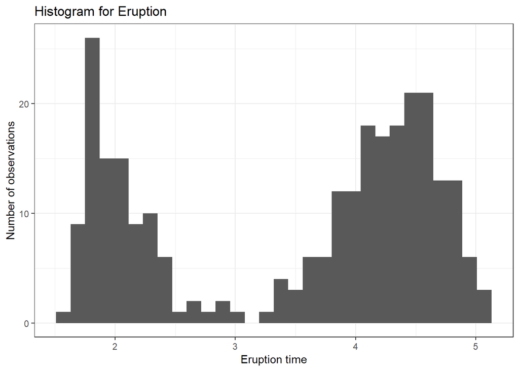

```r
ggplot(faithful, aes(x = eruptions), binwidth = 30) +
  geom_histogram() +
  labs(x = "Eruption time",
       y = "Number of observations",
       title = "Histogram for Eruption") +
  theme_bw()
```

The histogram shows eruption time falls between 0 and 6 minutes, and from summary statistics we know that the minimum duration for one eruption is 1.6 minutes, while the maximum is 5.1 minutes, which are not readily obvious from the histogram. Nonetheless, we are able to present the distribution of eruption time. In this case, observations are dense around 2 minutes, and again dense around 4-5 minutes range.

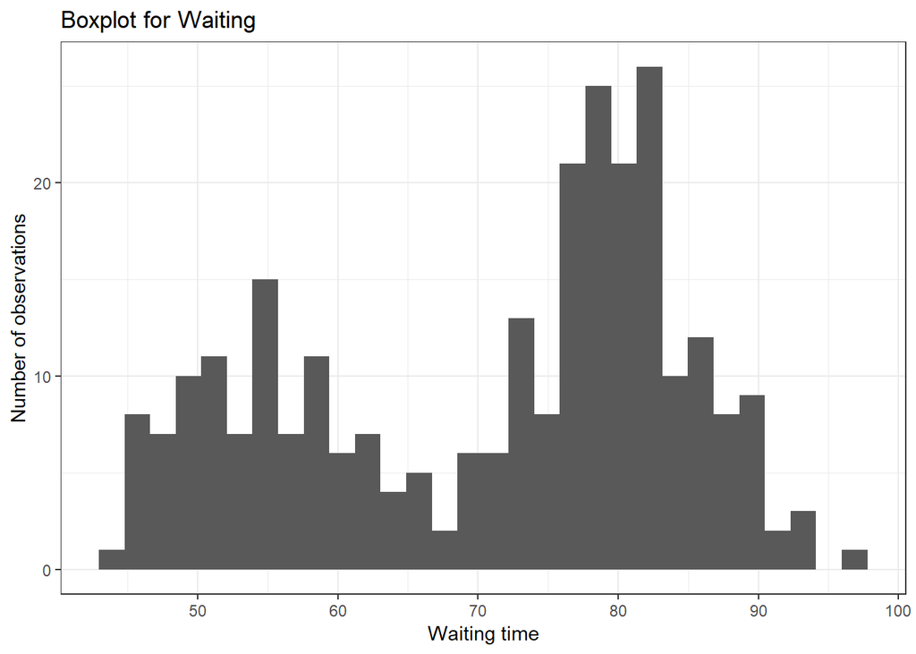

```r
ggplot(faithful, aes(x = waiting), binwidth = 30) +
  geom_histogram() +
  labs(x = "Waiting time",
       y = "Number of observations",
       title = "Boxplot for Waiting") +
  theme_bw()
```

According to the histogram, waiting time for watching geysur eruption falls under the range of 1 and 100 minutes. Similar to eruption time, we observe two peaks in the distribution of data points, one around 55 minutes and another around 80 minutes.

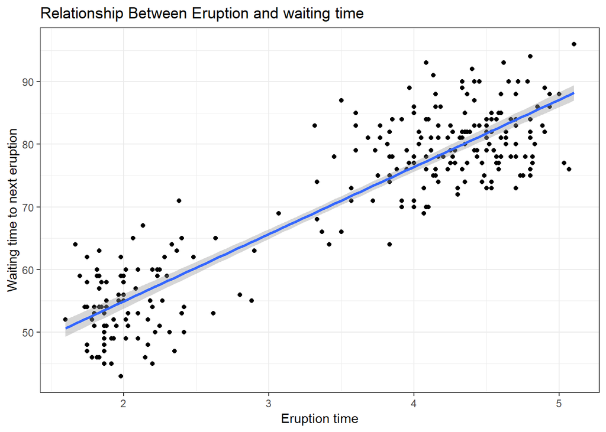

```r
ggplot(faithful, aes(x = eruptions, y = waiting)) +
  geom_point() +
  geom_smooth(method = lm) +
  labs(x = "Eruption time",
       y = "Waiting time to next eruption",
       title = "Relationship Between Eruption and waiting time") +
  theme_bw()
```

As shown by the graph, there seems to be a positive correlation between eruption time and waiting time, i.e. as the duration of eruption becomes longer, the waiting time required to see that eruption increases. Moreover, data points are concentrated in the top right corner and bottom left corner, meaning that we recognize high density for observations where eruption time and waiting time are both short or both long, with a gap in the middle.

### Question 5

Calculate dissimilarity matrix of the data

```r
library(seriation)
faithful_scaled <- scale(faithful)
dist(faithful_scaled, method="euclidean")
```

[output not shown]

[output cut: 14905 more lines]

[output not shown]

### Question 6

Generate an ODI for the faithful data

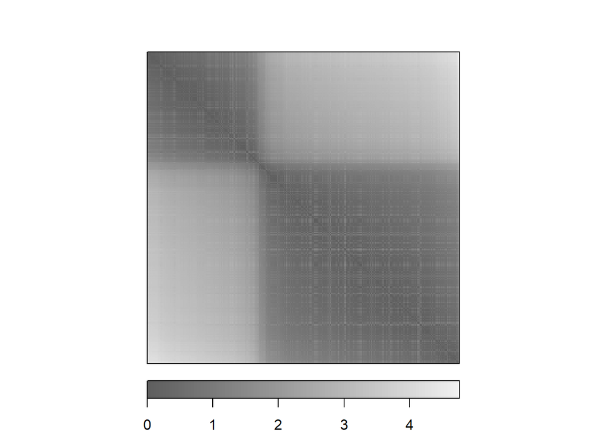

```r
faithful_dist <- dist(faithful_scaled,
               method = "euclidean")
dissplot(faithful_dist)
```

As shown in the fugure, greater spatial similarity is seen at the two dark blcoks along the diagonal, indicating there could be potential clusters, i.e. we have identified the data’s clusterability.

### Question 7

Use the iris data, creating a subset of the data excluding the species feature, scaling the features, and calculating a dissimilarity matrix

```r
data("iris")
summary(iris)
```

```
##   Sepal.Length    Sepal.Width     Petal.Length    Petal.Width
##  Min.   :4.300   Min.   :2.000   Min.   :1.000   Min.   :0.100
##  1st Qu.:5.100   1st Qu.:2.800   1st Qu.:1.600   1st Qu.:0.300
##  Median :5.800   Median :3.000   Median :4.350   Median :1.300
##  Mean   :5.843   Mean   :3.057   Mean   :3.758   Mean   :1.199
##  3rd Qu.:6.400   3rd Qu.:3.300   3rd Qu.:5.100   3rd Qu.:1.800
##  Max.   :7.900   Max.   :4.400   Max.   :6.900   Max.   :2.500
##        Species
##  setosa    :50
##  versicolor:50
##  virginica :50
##
##
##
```

```r
iris_sub <- iris %>%
  dplyr::select(Sepal.Length, Sepal.Width, Petal.Length, Petal.Width) %>%
  scale() %>%
  dist()
```

### Question 8

Fit HAC using complete linkage and render the dendrogram

```r
iris_sub
```

[output not shown]

[output cut: 3245 more lines]

[output not shown]

```r
library(dendextend)
```

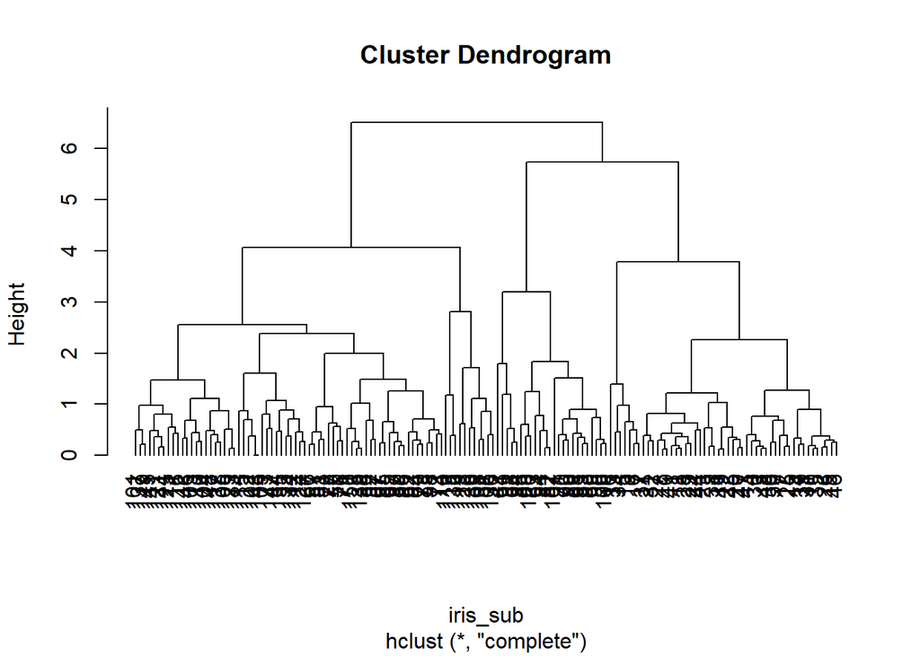

```r
hc_complete <- hclust(iris_sub,
                      method = "complete"); plot(hc_complete, xaxt = 'n', hang = -1)
```

The dendrogram shows us a bottom-up approach in pairing observations that hierarchically forms some forms of clusterings.

### Question 9

Cut the tree in 2 and 3 branches

```r
cuts <- cutree(hc_complete,
            k = c(2,3))
table(`2 Clusters` = cuts[,1],
      `3 Clusters` = cuts[,2])
```

```
##           3 Clusters
## 2 Clusters  1  2  3
##          1 49 24  0
##          2  0  0 77
```

Show trees

2 branches:

```r
#install.packages("factoextra")
library(factoextra)
```

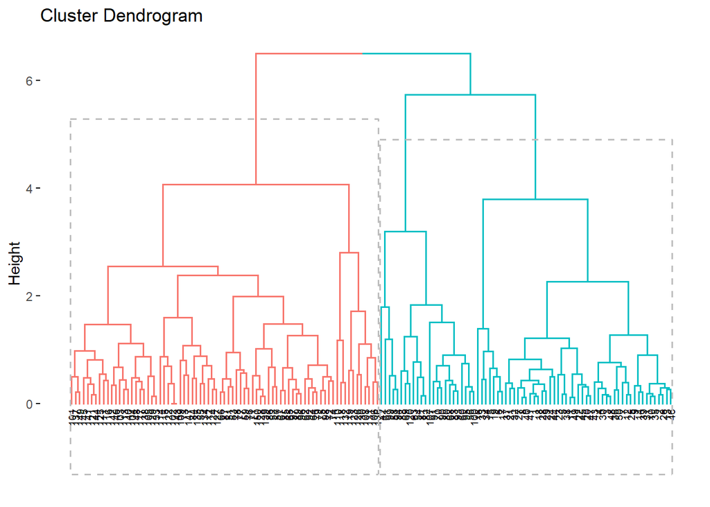

```r
fviz_dend(hc_complete, cex = 0.5, k = 2,
 color_labels_by_k = FALSE, rect = TRUE)
```

3 branches:

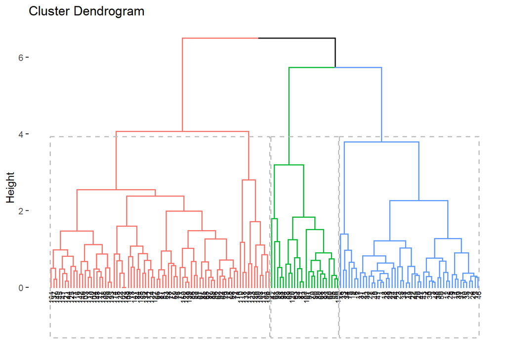

```r
fviz_dend(hc_complete, cex = 0.5, k = 3,
 color_labels_by_k = FALSE, rect = TRUE)
```

Show two trees side-by-side:

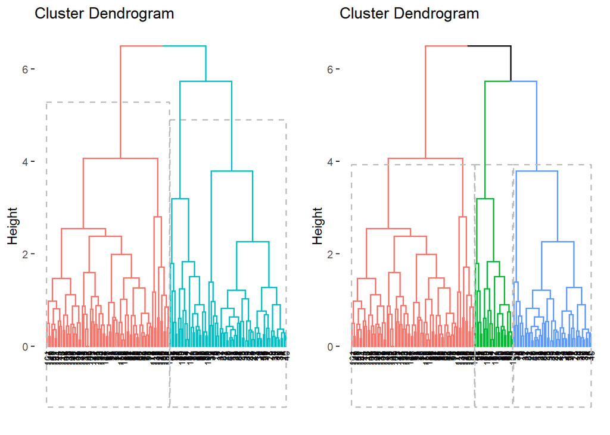

```r
par(mfrow = c(1,1))

p1 <- fviz_dend(hc_complete, cex = 0.5, k = 2,
 color_labels_by_k = FALSE, rect = TRUE)
p2 <- fviz_dend(hc_complete, cex = 0.5, k = 3,
 color_labels_by_k = FALSE, rect = TRUE)

#install.packages("grid")
library(grid)
library(gridExtra)
grid.arrange(p1, p2, ncol = 2)
```

We see from the trees that three-branch version is able to parse out an additional cluster of observations that share similarity from the previous information contained in the two-cluster model.

### Question 10

Fit HAC using single and complete linkage, render the dendrogram and compare clustering patterns

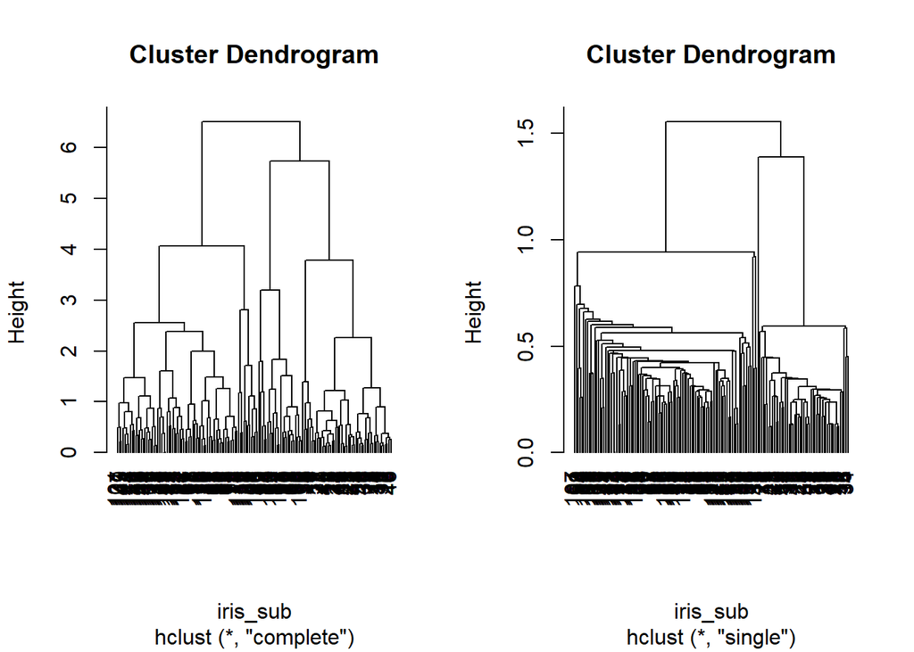

```r
library(dendextend)

par(mfrow = c(1,2))

hc_complete <- hclust(iris_sub,
                      method = "complete"); plot(hc_complete, xaxt = 'n', hang = -1)

hc_single <- hclust(iris_sub,
                      method = "single"); plot(hc_single, xaxt = 'n', hang = -1)
```

As we can see from comparing the two dendrograms, complete linkage produces a cleaner clustering by using the farthest points for intra-cluster distance, whereas single linkage produces somewhat straggling clusters with distance representing distance between data points closest to the other cluster.

## Critical thinking

### Question 1

1. It is important to make sure the underlying patterns are not random. We could repeat iterations from treecutting and inspect the assignment of observations to see if the pattern holds.
2. We could use the Hopkins statistic to assess the clusterability. If the value of H is below 0.5, it means the data contains meaningful clusterings. We can also use VAT, by plotting ordered dissimilarity image. If there are dark blocks along the diagonal, there is spacial similarity among some observations versus the other.
3. Both aforementioned techniques can be combined to double check the clusterability of a dataset. By coupling mathematically exploration with visual aid, we will form better informed decision on whether to pursue further this clustering.
4. If we couldn’t find clusterability with existing dataset, it might be worthwhile to add or drop some input variables before we decide to drop this exploratory analysis of the dataset, if the current one we are using is a subset of the broader universe.

### Question 2

1. The authors use a collection of DNA sequence data as initial data that feed into an algorithm that calculate the similarity in DNA between victim’s strand of virus and the accused patient’s strand, as compared to control group, thus establishing molecular evidence through phylogenetic trees.
2. While not following closely the step of assessing clusterability, in their phylogenetic analyses, the researchers in this case did make the effort to calculate maximum-likelihood distance in which large numbers of pairwise distances are computed, following criteria of parsimony. They also conducted many bootstrap replications to establish the strength of results.
3. The results show that DNA sequencing data for HIV sequences are highly heterogeneous for both patient and victim samples. An extension could be looking at the types of virus that are likely transmitted from animal to human. This makes computational tools like HAC useful for forensic investigations of disease transmission, which is particularly relevant to the development of cross-section collaboration between bioinformation science and public health.

Reference:

Metzker, Michael & Mindell, David & Liu, Xiao-Mei & Ptak, Roger & Gibbs, Richard & Hillis, David. (2002). Molecular evidence of HIV-1 transmission in a criminal case. Proceedings of the National Academy of Sciences of the United States of America. 99. 14292-7. 10.1073/pnas.222522599.